# Impacto del estrés térmico ambiental en la incidencia cardiovascular aguda: Un análisis con datos de reanálisis NASA/POWER

Fuentes de Datos Biomédicos y Web Semántica

Alex Sanz, Aurora Real y Nayara López de Armentia

2026-11-20

# 1. Introducción

## 1.1 Contexto Teórico

Se ha descrito que tanto el frío como el calor extremos se asocian con más morbilidad y mortalidad cardiovascular (Achebak et al., 2024), y en el norte de España se han observado más ingresos por infarto en invierno y relación con la temperatura aparente (Santurtún et al., 2019). Los mecanismos propuestos incluyen la vasoconstricción y las alteraciones de la presión arterial. Sin embargo, los resultados no son uniformes: algunos trabajos describen que, durante las olas de calor, el exceso de mortalidad cardiovascular no va acompañado de más ingresos hospitalarios (Hanzlíková et al., 2015), y los cambios bruscos de temperatura también se han vinculado con la mortalidad (Plavcová y Kyselý, 2009).

Este trabajo explora esa idea con datos públicos del INE y de NASA/POWER en cuatro provincias de clima contrastado.

Hipótesis de partida: las provincias con perfiles térmicos más extremos (más frías o con más cambios bruscos de un día a otro) presentarían tasas de altas por IAM más altas.

Variable de control: por indicación del profesor se incluye además una variable sin relación causal plausible con la salud cardiovascular, la fase lunar, para comprobar que los patrones observados no aparecen también con una variable arbitraria.

## 1.2 Objetivos

**Objetivo General:** Explorar si existe relación entre el perfil térmico de cuatro provincias españolas de clima contrastado y su tasa bruta de altas hospitalarias por infarto agudo de miocardio (IAM), incluyendo una variable de control sin relación causal plausible (la fase lunar).

**Objetivos Específicos:**

1. Comparar la morbilidad por infarto agudo de miocardio en 4 provincias españolas de contraste climático (Burgos, A Coruña, Las Palmas y Sevilla).
2. Integrar bases de datos epidemiológicas del INE con series climáticas diarias de NASA/POWER (reanálisis MERRA-2).
3. Describir, mediante indicadores térmicos (temperatura media y mínima, caída máxima interdiaria y número de días con cambios bruscos de al menos 3 °C), si los perfiles más extremos se corresponden con tasas de altas más altas.
4. Comprobar si una variable sin relación causal plausible (la fase lunar) muestra asociación con los indicadores térmicos diarios.

# 2. Metodología e Integración de Datos

## 2.1. Fuentes de datos y auditoría de metadatos

El flujo de trabajo se estructura dentro del proyecto de RStudio empleando exclusivamente **rutas relativas** (`INPUT/DATA/` y `OUTPUT/`), evitando el uso de `setwd()` para garantizar la reproducibilidad del análisis.

Se han integrado tres fuentes heterogéneas de datos: 1. **Morbilidad hospitalaria (`infartos_españa.csv`):** Altas hospitalarias por infarto agudo de miocardio (CIE-10-MC I21-I22) procedentes del Instituto Nacional de Estadística (INE), correspondientes al año 2024. 2. **Demografía provincial (`poblacion_provincias.csv`):** Cifras oficiales de población del INE a 1 de julio de 2024 desagregadas por provincia y sexo, indispensables para transformar los recuentos brutos en tasas comparables por cada 100.000 habitantes. 3. **Datos climáticos (`temperaturas_*.json`):** Series diarias de temperatura media a 2 metros (`T2M`) y temperatura mínima (`T2M_MIN`) del proyecto **NASA/POWER** en formato GeoJSON, del 1 de enero al 12 de julio de 2024 (194 días; el primer día se pierde al calcular el choque térmico, por lo que los indicadores se calculan sobre 193). Proceden del reanálisis MERRA-2, un modelo atmosférico que asimila observaciones de satélite y de superficie, por lo que no son mediciones directas de una estación.

**Nota sobre las coordenadas:** el archivo `temperaturas_santiago.json` corresponde a Santiago de Compostela (42,887 N; -8,568 E; 227 m), que es el punto que representa a la provincia de A Coruña en este trabajo. Burgos se sitúa a 918 m de altitud, lo que contribuye a su perfil frío.

## 2.2. Paquetes utilizados

- `tidyverse`: importación, limpieza, transformación y gráficos (`readr`, `dplyr`, `ggplot2`…).
- `jsonlite`: lectura de los archivos GeoJSON de NASA/POWER.
- `lunar`: cálculo de la fase lunar a partir de la fecha.
- `DT` y `plotly`: tablas y gráficos interactivos.
- `sf` y `mapSpain`: cartografía de las provincias españolas.

## 2.3. Procesamiento

En el siguiente bloque se importan los CSV y los JSON, se limpian y se integran en una sola tabla. Los pasos son: (1) importar el INE respetando la codificación y el separador de miles; (2) filtrar las cuatro provincias; (3) extraer metadatos de los JSON con una función propia; (4) convertir las series diarias a formato ordenado con otra función propia; (5) convertir el valor nulo de la NASA (-999) en `NA`; (6) calcular el choque térmico (temperatura de hoy menos la de ayer) y la fase lunar; (7) calcular indicadores por provincia y la tasa por 100.000 habitantes; (8) guardar el entorno y recargarlo.

```r
library(tidyverse)
library(jsonlite)
library(lunar)
library(DT)
library(plotly)
library(sf)
library(mapSpain)
# 1. Importamos el CSV de infartos del INE protegiendo tildes y separador de miles (".")
datos_ine <- read_delim(
  "INPUT/DATA/infartos_españa.csv",
  delim = ";",
  locale = locale(encoding = "ISO-8859-1", grouping_mark = ".")
)

# 2. Importamos el CSV de población del INE
datos_poblacion <- read_delim(
  "INPUT/DATA/poblacion_provincias.csv",
  delim = ";",
  locale = locale(encoding = "ISO-8859-1", grouping_mark = ".")
)

# 3. Inspección de estructura y valores nulos (auditoría de metadatos INE)
str(datos_ine)
```

```
## spc_tbl_ [132 × 6] (S3: spec_tbl_df/tbl_df/tbl/data.frame)
##  $ Sexo                            : chr [1:132] "Ambos sexos" "Ambos sexos" "Ambos sexos" "Ambos sexos" ...
##  $ Diagnóstico principal (CIE10MC) : chr [1:132] "0903 Infarto agudo de miocardio I21-I22" "0903 Infarto agudo de miocardio I21-I22" "0903 Infarto agudo de miocardio I21-I22" "0903 Infarto agudo de miocardio I21-I22" ...
##  $ Total Nacional                  : chr [1:132] "Total Nacional" "Total Nacional" "Total Nacional" "Total Nacional" ...
##  $ Comunidades y Ciudades Autónomas: chr [1:132] NA "01 Andalucía" "01 Andalucía" "01 Andalucía" ...
##  $ Provincias                      : chr [1:132] NA "04 Almería" "11 Cádiz" "14 Córdoba" ...
##  $ Total                           : num [1:132] 59498 877 1720 944 1154 ...
##  - attr(*, "spec")=
##   .. cols(
##   ..   Sexo = col_character(),
##   ..   `Diagnóstico principal (CIE10MC)` = col_character(),
##   ..   `Total Nacional` = col_character(),
##   ..   `Comunidades y Ciudades Autónomas` = col_character(),
##   ..   Provincias = col_character(),
##   ..   Total = col_number()
##   .. )
##  - attr(*, "problems")=<externalptr>
```

```r
colSums(is.na(datos_ine))
```

```
##                             Sexo  Diagnóstico principal (CIE10MC)
##                                0                                0
##                   Total Nacional Comunidades y Ciudades Autónomas
##                                0                                3
##                       Provincias                            Total
##                                3                                0
```

```r
# 4. Filtramos las 4 provincias de estudio y estandarizamos la categoría "Ambos sexos"
provincias_estudio <- c("09 Burgos", "41 Sevilla", "35 Palmas, Las", "15 Coruña, A")

infartos_limpio <- datos_ine %>%
  filter(Provincias %in% provincias_estudio)

poblacion_limpio <- datos_poblacion %>%
  filter(
    Provincias %in% provincias_estudio,
    `Edad simple` == "Todas las edades"
  ) %>%
  mutate(Sexo = ifelse(Sexo == "Total", "Ambos sexos", Sexo)) %>%
  select(Provincias, Sexo, Poblacion = Total)

# Comprobamos que ambas tablas tienen 12 filas (4 provincias x 3 categorías de sexo)
table(infartos_limpio$Provincias)
```

```
##
##      09 Burgos   15 Coruña, A 35 Palmas, Las     41 Sevilla
##              3              3              3              3
```

```r
table(poblacion_limpio$Provincias)
```

```
##
##      09 Burgos   15 Coruña, A 35 Palmas, Las     41 Sevilla
##              3              3              3              3
```

```r
# 1. Importación de los 4 GeoJSON
json_burgos    <- fromJSON("INPUT/DATA/temperaturas_burgos.json", simplifyVector = TRUE)
json_sevilla   <- fromJSON("INPUT/DATA/temperaturas_sevilla.json", simplifyVector = TRUE)
json_coruna    <- fromJSON("INPUT/DATA/temperaturas_santiago.json", simplifyVector = TRUE)
json_laspalmas <- fromJSON("INPUT/DATA/temperaturas_laspalmas.json", simplifyVector = TRUE)

# 2. Función propia para extraer metadatos espaciales y técnicos de cada JSON
extraer_metadatos_nasa <- function(datos_json, nombre_provincia) {
  coords <- datos_json$geometry$coordinates
  tibble(
    Provincia       = nombre_provincia,
    Longitud        = coords[1],
    Latitud         = coords[2],
    Altitud_m       = coords[3],
    Fuente          = datos_json$header$title,
    Valor_Nulo_NASA = datos_json$header$fill_value,
    Unidad          = datos_json$parameters$T2M$units
  )
}

tabla_metadatos <- bind_rows(
  extraer_metadatos_nasa(json_burgos,    "09 Burgos"),
  extraer_metadatos_nasa(json_sevilla,   "41 Sevilla"),
  extraer_metadatos_nasa(json_coruna,    "15 Coruña, A"),
  extraer_metadatos_nasa(json_laspalmas, "35 Palmas, Las")
)

datatable(tabla_metadatos, options = list(dom = "t", scrollX = TRUE))
```

|  | Provincia | Longitud | Latitud | Altitud_m | Fuente | Valor_Nulo_NASA | Unidad |
| --- | --- | --- | --- | --- | --- | --- | --- |
| 1 | 09 Burgos | -3.701 | 42.341 | 917.61 | NASA/POWER Source Native Resolution Daily Data | -999 | C |
| 2 | 41 Sevilla | -5.997 | 37.382 | 187.78 | NASA/POWER Source Native Resolution Daily Data | -999 | C |
| 3 | 15 Coruña, A | -8.568 | 42.887 | 226.66 | NASA/POWER Source Native Resolution Daily Data | -999 | C |
| 4 | 35 Palmas, Las | -15.433 | 28.127 | 109.29 | NASA/POWER Source Native Resolution Daily Data | -999 | C |

```r
# 3. Función propia para transformar las series diarias JSON en tabla ordenada
limpiar_json_nasa <- function(datos_json, nombre_provincia) {
  lista_t2m     <- datos_json$properties$parameter$T2M
  lista_t2m_min <- datos_json$properties$parameter$T2M_MIN

  tibble(
    Provincias = nombre_provincia,
    Fecha      = as.Date(names(lista_t2m), format = "%Y%m%d"),
    T2M        = as.numeric(unlist(lista_t2m)),
    T2M_MIN    = as.numeric(unlist(lista_t2m_min))
  )
}

clima_total <- bind_rows(
  limpiar_json_nasa(json_burgos,    "09 Burgos"),
  limpiar_json_nasa(json_sevilla,   "41 Sevilla"),
  limpiar_json_nasa(json_coruna,    "15 Coruña, A"),
  limpiar_json_nasa(json_laspalmas, "35 Palmas, Las")
)

# 4. Control de calidad (-999 -> NA) y cálculo de Choque Térmico y Fase Lunar
datos_ambientales <- clima_total %>%
  mutate(
    T2M     = ifelse(T2M == -999, NA, T2M),
    T2M_MIN = ifelse(T2M_MIN == -999, NA, T2M_MIN)
  ) %>%
  group_by(Provincias) %>%
  mutate(
    Temp_Ayer      = lag(T2M),
    Choque_Termico = T2M - Temp_Ayer,
    Fase_Lunar     = lunar.phase(Fecha, name = TRUE)
  ) %>%
  ungroup() %>%
  filter(!is.na(Choque_Termico))



# 1. Resumen ambiental por provincia
resumen_ambiental <- datos_ambientales %>%
  group_by(Provincias) %>%
  summarise(
    Temp_Media         = round(mean(T2M, na.rm = TRUE), 2),
    Temp_Min_Absoluta  = round(min(T2M_MIN, na.rm = TRUE), 2),
    Choque_Max_Caida   = round(min(Choque_Termico, na.rm = TRUE), 2),
    Dias_Choque_Brusco = sum(abs(Choque_Termico) >= 3, na.rm = TRUE),
    Dias_Luna_Llena    = sum(Fase_Lunar == "Full", na.rm = TRUE),
    .groups = "drop"
  )

# 2. Unión de infartos + población + indicadores climáticos y cálculo de Tasa_100k
estudio_por_sexo <- infartos_limpio %>%
  left_join(poblacion_limpio, by = c("Provincias", "Sexo")) %>%
  left_join(resumen_ambiental, by = "Provincias") %>%
  mutate(Tasa_100k = round((Total / Poblacion) * 100000, 2))

# Tabla filtrada para ambos sexos
estudio_completo <- estudio_por_sexo %>%
  filter(Sexo == "Ambos sexos")

# 3. Exportamos el dataset integrado a CSV
write_csv(estudio_por_sexo, file = "OUTPUT/estudio_integrado_infartos_nasa.csv")

# 4. Guardamos objetos en .RData, vaciamos el Global Environment y restablecemos
save(
  tabla_metadatos,
  datos_ambientales,
  resumen_ambiental,
  estudio_por_sexo,
  estudio_completo,
  file = "OUTPUT/datos_seminario.RData"
)

rm(list = ls())
load("OUTPUT/datos_seminario.RData")
ls()
```

```
## [1] "datos_ambientales" "estudio_completo"  "estudio_por_sexo"
## [4] "resumen_ambiental" "tabla_metadatos"
```

# 3. Resultados y Análisis Visual

La homeostasis cardiovascular depende estrechamente de la termorregulación. Ante descensos térmicos ambientales, la activación de termorreceptores cutáneos desencadena una descarga simpática reflejada en vasoconstricción periférica $\alpha$-adrenérgica, aumento de la resistencia vascular periférica y elevación de la presión arterial sistólica y diastólica. Este fenómeno incrementa abruptamente la **poscarga del ventrículo izquierdo** y la demanda miocárdica de oxígeno, favoreciendo la rotura de placas ateroscleróticas vulnerables y la trombosis coronaria.

A continuación se presentan los resultados integrados mediante tablas, gráficos interactivos y mapas. Al comparar solo cuatro provincias mediante tasas brutas, el análisis es exploratorio.

## 3.1 Tabla de Datos Integrados

```r
datatable(estudio_completo, options = list(dom = "t", scrollX = TRUE))
```

|  | Sexo | Diagnóstico principal (CIE10MC) | Total Nacional | Comunidades y Ciudades Autónomas | Provincias | Total | Poblacion | Temp_Media | Temp_Min_Absoluta | Choque_Max_Caida | Dias_Choque_Brusco | Dias_Luna_Llena | Tasa_100k |
| --- | --- | --- | --- | --- | --- | --- | --- | --- | --- | --- | --- | --- | --- |
| 1 | Ambos sexos | 0903 Infarto agudo de miocardio I21-I22 | Total Nacional | 01 Andalucía | 41 Sevilla | 2365 | 1971903 | 17.36 | 1.28 | -5.57 | 19 | 45 | 119.93 |
| 2 | Ambos sexos | 0903 Infarto agudo de miocardio I21-I22 | Total Nacional | 05 Canarias | 35 Palmas, Las | 1623 | 1165222 | 20.11 | 16.58 | -1.08 | 0 | 45 | 139.29 |
| 3 | Ambos sexos | 0903 Infarto agudo de miocardio I21-I22 | Total Nacional | 07 Castilla y León | 09 Burgos | 416 | 360525 | 9.85 | -6.23 | -7.66 | 39 | 45 | 115.39 |
| 4 | Ambos sexos | 0903 Infarto agudo de miocardio I21-I22 | Total Nacional | 12 Galicia | 15 Coruña, A | 1685 | 1130214 | 12.65 | -0.86 | -3.99 | 13 | 45 | 149.09 |

## 3.2 Análisis Visual y Exploración Fisiopatológica

### Perfil Térmico y Tasa Bruta

**Justificación fisiológica:** La exposición sostenida a temperaturas medias bajas (`T2M`) induce un estado basal de hiperactividad simpática, hemoconcentración y aumento de factores procoagulantes (fibrinógeno y viscosidad plasmática), lo que teóricamente incrementaría la incidencia acumulada de eventos isquémicos. Esta primera visualización contrasta la tasa bruta de altas hospitalarias frente a la temperatura media y la frecuencia de episodios bruscos en cada provincia.

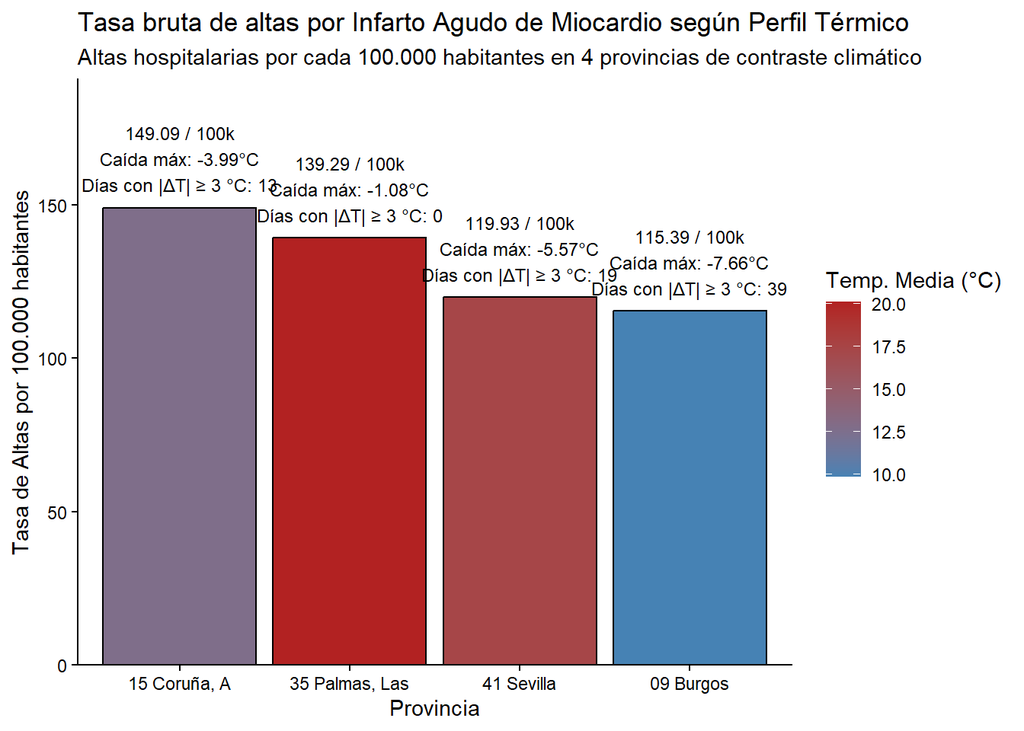

```r
# GRÁFICA 1: Tasa bruta de altas por IAM (por 100.000 hab.) vs Perfil Térmico
grafico_principal <- ggplot(estudio_completo, aes(x = reorder(Provincias, -Tasa_100k), y = Tasa_100k, fill = Temp_Media)) +
  geom_col(colour = "black") +
  geom_text(
    aes(label = paste0(Tasa_100k, " / 100k\nCaída máx: ", Choque_Max_Caida, "°C\nDías con |ΔT| ≥ 3 °C: ", Dias_Choque_Brusco)),
    vjust = -0.25,
    size = 3.1
  ) +
  scale_fill_gradient(low = "steelblue", high = "firebrick") +
  scale_y_continuous(expand = expansion(mult = c(0, 0.28))) +
  labs(
    title = "Tasa bruta de altas por Infarto Agudo de Miocardio según Perfil Térmico",
    subtitle = "Altas hospitalarias por cada 100.000 habitantes en 4 provincias de contraste climático",
    x = "Provincia",
    y = "Tasa de Altas por 100.000 habitantes",
    fill = "Temp. Media (°C)"
  ) +
  theme_classic()

ggsave(filename = "grafico_1_tasa_clima.png", plot = grafico_principal, path = "OUTPUT", width = 22, height = 13, units = "cm", dpi = 300)
grafico_principal
```

### Estratificación por Sexo

**Justificación fisiológica:** La susceptibilidad al estrés térmico y a la cardiopatía isquémica presenta un marcado dimorfismo sexual. Los estrógenos endógenos ejercen un efecto cardioprotector mediante la vasodilatación mediada por óxido nítrico endotelial y la atenuación de la respuesta vasoconstrictora simpática frente al frío, mientras que los varones desarrollan aterosclerosis coronaria obstructiva a edades más tempranas. Desagregar las tasas por sexo permite comprobar si la brecha biológica se mantiene constante con independencia del clima provincial.

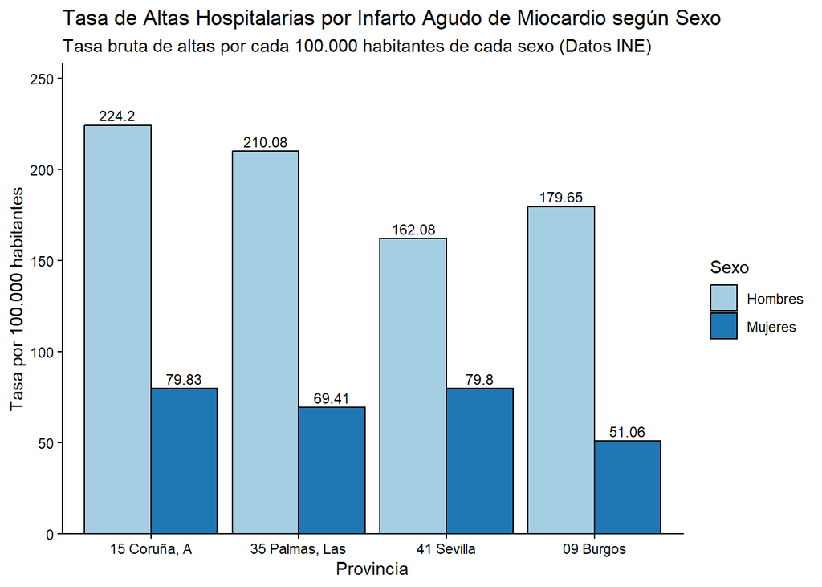

```r
# GRÁFICA 2: Comparativa de tasa bruta por Sexo y Provincia
grafico_sexo <- estudio_por_sexo %>%
  filter(Sexo != "Ambos sexos") %>%
  ggplot(aes(x = reorder(Provincias, -Tasa_100k), y = Tasa_100k, fill = Sexo)) +
  geom_col(position = "dodge", colour = "black") +
  geom_text(
    aes(label = Tasa_100k),
    position = position_dodge(width = 0.9),
    vjust = -0.4,
    size = 3.1
  ) +
  scale_fill_brewer(palette = "Paired") +
  scale_y_continuous(expand = expansion(mult = c(0, 0.15))) +
  labs(
    title = "Tasa de Altas Hospitalarias por Infarto Agudo de Miocardio según Sexo",
    subtitle = "Tasa bruta de altas por cada 100.000 habitantes de cada sexo (Datos INE)",
    x = "Provincia",
    y = "Tasa por 100.000 habitantes",
    fill = "Sexo"
  ) +
  theme_classic()

ggsave(filename = "grafico_2_tasa_sexo.png", plot = grafico_sexo, path = "OUTPUT", width = 22, height = 13, units = "cm", dpi = 300)
grafico_sexo
```

### Dispersión: Choque Térmico Máximo

**Justificación fisiológica y estadística:** Más allá del frío sostenido, las caídas térmicas bruscas entre días consecutivos ($\Delta T = T_{\text{hoy}} - T_{\text{ayer}} < 0$) impiden la aclimatación vascular progresiva, pudiendo desencadenar vasoespasmo coronario agudo y picos hipertensivos repentinos. Para explorar si la caída térmica máxima interdiaria (`Choque_Max_Caida`) se asocia linealmente con la carga hospitalaria (`Tasa_100k`), se ajusta una recta de regresión lineal orientativa (`method = "lm"`, $n = 4$) en formato interactivo.

```r
grafico_dispersion <- ggplot(estudio_completo, aes(x = Choque_Max_Caida, y = Tasa_100k)) +
  geom_point(
    aes(color = Provincias,
        text = paste0(Provincias, "<br>Tasa: ", Tasa_100k, "<br>Choque Máx: ", Choque_Max_Caida, " ºC")),
    size = 4.5
  ) +
  geom_smooth(method = "lm", se = FALSE, color = "darkgray", linetype = "dashed") +
  geom_text(aes(label = Provincias), vjust = -1.1, size = 3.4) +
  scale_y_continuous(expand = expansion(mult = c(0.15, 0.20))) +
  scale_x_continuous(expand = expansion(mult = c(0.15, 0.15))) +
  labs(
    title = "Relación entre la Severidad del Choque Térmico y la Tasa de Infartos",
    subtitle = "Recta orientativa (solo 4 provincias) entre la caída térmica máxima interdiaria (ΔT) y la tasa por 100.000 hab.",
    x = "Choque Térmico Máximo Interdiario — Caída ΔT (°C)",
    y = "Tasa de Altas por 100.000 habitantes",
    color = "Provincia"
  ) +
  theme_classic() +
  theme(legend.position = "none")

ggsave(filename = "grafico_3_dispersion_choque.png", plot = grafico_dispersion, path = "OUTPUT", width = 22, height = 13, units = "cm", dpi = 300)

# Esto fuerza la interactividad con Plotly
grafico_dispersion_interactivo <- ggplotly(grafico_dispersion, tooltip = "text") %>%
  layout(
    hoverlabel = list(bgcolor = "white", bordercolor = "black", font = list(color = "black"))
  )
grafico_dispersion_interactivo
```

[interactive chart not shown]

### Frecuencia de Choques Bruscos

**Justificación fisiológica:** Un único episodio extremo anual puede no reflejar el desgaste acumulado del sistema cardiovascular. Evaluar el número total de días con oscilaciones bruscas ($|\Delta T| \ge 3\text{ }^\circ\text{C}$) permite explorar si la repetición de estímulos vasoconstrictores y vasodilatadores agudos se relaciona con una mayor tasa de ingresos hospitalarios.

```r
# Indicadores térmicos por provincia junto a la tasa bruta
tabla_indicadores <- estudio_completo %>%
  select(Provincias, Tasa_100k, Temp_Media, Temp_Min_Absoluta,
         Choque_Max_Caida, Dias_Choque_Brusco) %>%
  arrange(desc(Tasa_100k))

datatable(tabla_indicadores, options = list(dom = "t", scrollX = TRUE))
```

|  | Provincias | Tasa_100k | Temp_Media | Temp_Min_Absoluta | Choque_Max_Caida | Dias_Choque_Brusco |
| --- | --- | --- | --- | --- | --- | --- |
| 1 | 15 Coruña, A | 149.09 | 12.65 | -0.86 | -3.99 | 13 |
| 2 | 35 Palmas, Las | 139.29 | 20.11 | 16.58 | -1.08 | 0 |
| 3 | 41 Sevilla | 119.93 | 17.36 | 1.28 | -5.57 | 19 |
| 4 | 09 Burgos | 115.39 | 9.85 | -6.23 | -7.66 | 39 |

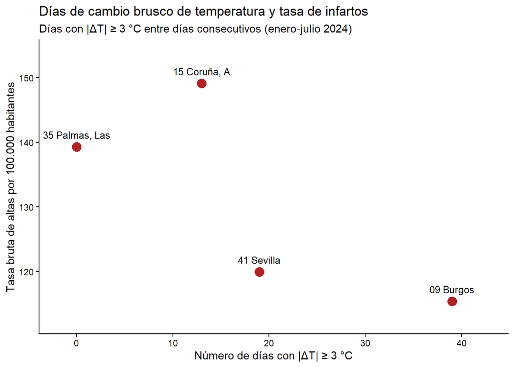

```r
ggplot(tabla_indicadores, aes(x = Dias_Choque_Brusco, y = Tasa_100k, label = Provincias)) +
  geom_point(size = 4, colour = "firebrick") +
  geom_text(vjust = -1.1, size = 3.4) +
  scale_x_continuous(expand = expansion(mult = c(0.1, 0.15))) +
  scale_y_continuous(expand = expansion(mult = c(0.15, 0.2))) +
  labs(
    title = "Días de cambio brusco de temperatura y tasa de infartos",
    subtitle = "Días con |ΔT| ≥ 3 °C entre días consecutivos (enero-julio 2024)",
    x = "Número de días con |ΔT| ≥ 3 °C",
    y = "Tasa bruta de altas por 100.000 habitantes"
  ) +
  theme_classic()
```

### Variable de Control: Fase Lunar

**Justificación metodológica y cronobiológica:** Por indicación del profesor se incluye una variable sin plausibilidad biológica ni mecanismo fisiopatológico conocido sobre la trombosis coronaria o la termorregulación: la fase lunar. Dado que cada fecha tiene una única fase idéntica en todo el territorio, este bloque actúa como control negativo para verificar si el choque térmico medio diario ($|\Delta T|$) muestra variaciones aleatorias entre fases.

```r
luna_clima <- datos_ambientales %>%
  group_by(Provincias, Fase_Lunar) %>%
  summarise(
    Choque_Medio = round(mean(abs(Choque_Termico), na.rm = TRUE), 2),
    Dias         = n(),
    .groups = "drop"
  )

datatable(luna_clima, options = list(dom = "t", scrollX = TRUE))
```

|  | Provincias | Fase_Lunar | Choque_Medio | Dias |
| --- | --- | --- | --- | --- |
| 1 | 09 Burgos | New | 2.02 | 51 |
| 2 | 09 Burgos | Waxing | 1.83 | 47 |
| 3 | 09 Burgos | Full | 1.6 | 45 |
| 4 | 09 Burgos | Waning | 1.66 | 50 |
| 5 | 15 Coruña, A | New | 1.68 | 51 |
| 6 | 15 Coruña, A | Waxing | 1.1 | 47 |
| 7 | 15 Coruña, A | Full | 1.18 | 45 |
| 8 | 15 Coruña, A | Waning | 1.05 | 50 |
| 9 | 35 Palmas, Las | New | 0.44 | 51 |
| 10 | 35 Palmas, Las | Waxing | 0.41 | 47 |

[output cut: 6 more lines]

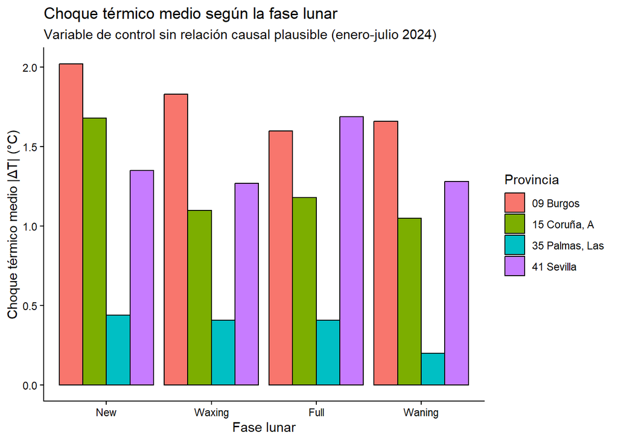

```r
grafico_luna <- ggplot(luna_clima, aes(x = Fase_Lunar, y = Choque_Medio, fill = Provincias)) +
  geom_col(position = "dodge", colour = "black") +
  labs(
    title = "Choque térmico medio según la fase lunar",
    subtitle = "Variable de control sin relación causal plausible (enero-julio 2024)",
    x = "Fase lunar",
    y = "Choque térmico medio |ΔT| (°C)",
    fill = "Provincia"
  ) +
  theme_classic()

ggsave(filename = "grafico_4_luna_choque.png", plot = grafico_luna, path = "OUTPUT", width = 22, height = 13, units = "cm", dpi = 300)
grafico_luna
```

### Distribución Espacial (Mapa)

**Justificación geográfica:** La representación cartográfica mediante `mapSpain` permite contextualizar la distribución espacial de las tasas brutas frente a factores geográficos moduladores del clima, como la continentalidad y la altitud (Burgos a 918 m) frente a la amortiguación térmica oceánica (A Coruña) o subtropical (Las Palmas).

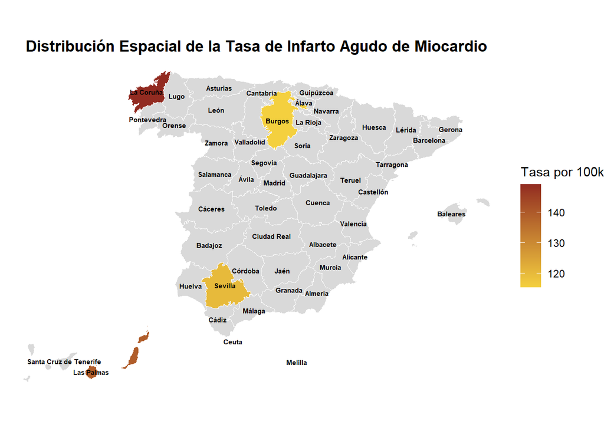

```r
library(sf)
library(mapSpain)

mapa_espana_prov <- esp_get_prov(moveCAN = TRUE)

estudio_corregido_mapa <- estudio_completo %>%
  mutate(
    cpro = case_when(
            Provincias == "09 Burgos" ~ "09",
      Provincias == "41 Sevilla" ~ "41",
      Provincias == "35 Palmas, Las" ~ "35",
      Provincias == "15 Coruña, A" ~ "15",
      TRUE ~ NA_character_
    )
  )

mapa_con_datos <- mapa_espana_prov %>%
  left_join(estudio_corregido_mapa, by = "cpro")

mapa_intensidad <- ggplot(data = mapa_con_datos) +
  geom_sf(aes(fill = Tasa_100k), color = "white", size = 0.2) +
  geom_sf_text(aes(label = prov.shortname.es), size = 2, color = "black", fontface = "bold", check_overlap = TRUE) +
  scale_fill_gradient(low = "#F4D03F", high = "#922B21", name = "Tasa por 100k", na.value = "gray85") +
  theme_void() +
  labs(title = "Distribución Espacial de la Tasa de Infarto Agudo de Miocardio") +
  theme(
    legend.position = "right",
    plot.title = element_text(hjust = 0.5, face = "bold")
  )

mapa_intensidad
```

# 4. Conclusiones

# 5. Limitaciones

- **Desajuste temporal:** el clima cubre 194 días (enero-julio de 2024) y las altas del INE son anuales; la población es de julio de 2024. Los resultados son asociaciones ecológicas entre provincias, no causalidad individual.
- **Muestra mínima:** con n = 4 provincias, la recta de regresión es orientativa y no permite inferencia estadística.
- **Variable de resultado:** las altas hospitalarias no equivalen a incidencia. Incluyen reingresos y no recogen los infartos que no llegan a hospitalización. Habría que comprobar si el INE las asigna por provincia de residencia o del hospital.
- **Fuente climática:** NASA/POWER es un reanálisis con malla de unas decenas de kilómetros, no una estación. Un único punto representa a toda la provincia (en A Coruña, Santiago de Compostela).
- **Factores no controlados:** edad, prevalencia de factores de riesgo cardiovascular y acceso a la atención sanitaria.

# 6. Referencias

- Instituto Nacional de Estadística (INE). (2024). *Encuesta de Morbilidad Hospitalaria: altas por diagnóstico, provincia y sexo*. https://www.ine.es
- Instituto Nacional de Estadística (INE). (2024). *Cifras de población por provincias, 1 de julio de 2024*. https://www.ine.es
- NASA Prediction Of Worldwide Energy Resources (POWER). (2024). *Daily API, parámetros T2M y T2M_MIN*. https://power.larc.nasa.gov/
- Gelaro, R., et al. (2017). The Modern-Era Retrospective Analysis for Research and Applications, Version 2 (MERRA-2). *Journal of Climate, 30*(14), 5419-5454.
- Wickham, H., et al. (2019). Welcome to the tidyverse. *Journal of Open Source Software, 4*(43), 1686.
- Achebak, H., Rey, G., Lloyd, S. J., Quijal-Zamorano, M., Méndez-Turrubiates, R. F., & Ballester, J. (2024). Ambient temperature and risk of cardiovascular and respiratory adverse health outcomes: a nationwide cross-sectional study from Spain. PMID 38364198. https://pubmed.ncbi.nlm.nih.gov/38364198/
- Santurtún, A., Fdez-Arroyabe, P., Royé, D., Zarrabeitia, M. T., & Álvarez Gutiérrez, A. (2019). Papel de la temperatura aparente y de los contaminantes atmosféricos en los ingresos por infarto agudo de miocardio en el norte de España. *Revista Española de Cardiología, 72*, 634-640. https://doi.org/10.1016/j.recesp.2018.05.032
- Hanzlíková, H., Plavcová, E., Kynčl, J., Kříž, B., & Kyselý, J. (2015). Contrasting patterns of hot spell effects on morbidity and mortality for cardiovascular diseases in the Czech Republic, 1994-2009. *International Journal of Biometeorology, 59*(11), 1673-1684. https://pubmed.ncbi.nlm.nih.gov/25744153
- Plavcová, E., & Kyselý, J. (2009). Effects of sudden air temperature and pressure changes on mortality in the Czech Republic. *Epidemiologie, mikrobiologie, imunologie*. https://www.prolekare.cz/en/journals/epidemiology-microbiology-immunology/2009-2/effects-of-sudden-air-temperature-and-pressure-changes-on-mortality-in-the-czech-republic-4683